# Ford GoBike Dataset

## by Caio Vasconcelos Silva Andrade

## Investigation Overview

> The Ford Gobike system, a bike-sharing system covering the greater San Francisco Bay area, now know as Bay Wheels, is the first regional and large-scale bicycle sharing system deployed in California and on the West Coast of the United States with nearly 500,000 rides since the launch in 2017 and had about 10,000 annual subscribers as of January 2018. As of January 2018, the Bay Wheels system had over 2,600 bicycles in 262 stations across San Francisco, East Bay and San Jose, this visualization studies a dataset from 2018 counts with 183412 values with features like gender, stations name and other ones

## Dataset Overview

> The dataset used for the analysis is from January 2018 to December 2018, counting with features like gender, duration in seconds of the trips and others, the data is saved on a CSV. Visualizations below are created from some wrangling and cleanning realized on the data to facilitate exploration analysis.

## User type (Subscription), Gender and days of the week

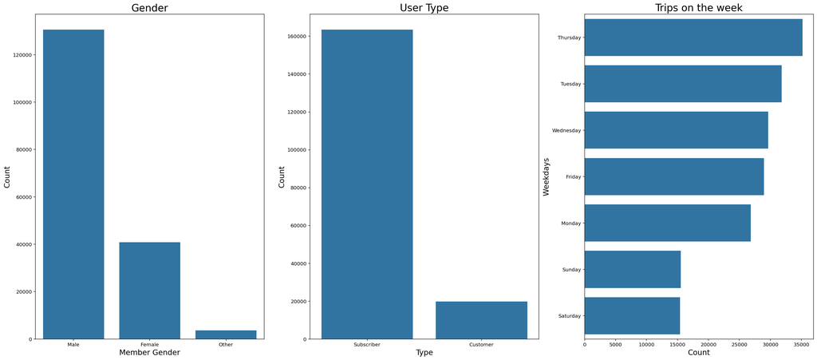

## Gender and Duration

> - In this plot we can see the duration in seconds of the trips by each sex!
> - We can see that the Womens are renting the bicicles for a longer period of time!

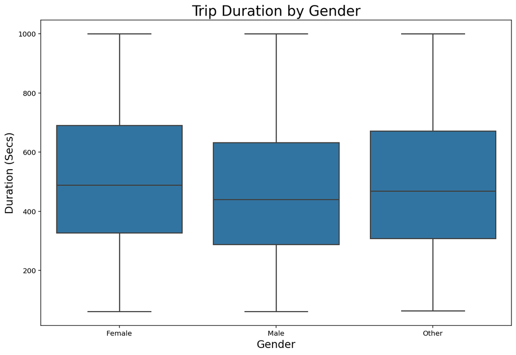

## Weekday, user type and duration

> - In this last plot we can see that the subscribers are renting for a smaller amount of time compared to the normal Customer
> - There is an intersting behavior... while on sunday and saturday, the Subscriber rent the bicicle for a smaller time compared to the other days, the Costumer does the opposity! The normal costumer is renting for a longer period than the other days!

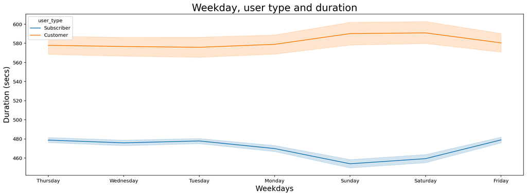